# Group4-KKT,KYJ,KYR,SJH

# 3-31 Cali

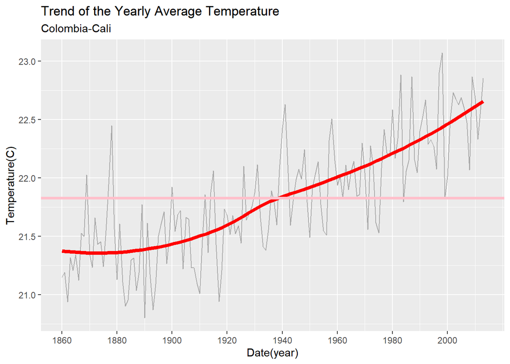

```r
# KIM KYU TAE
# Cali

city9 <- yclean %>% filter(City==part1_cities[17]) %>% na.omit()
city9 %>% group_by(year) %>% summarise(ave = mean(AverageTemperature)) %>% na.omit() %>%
  ggplot() + geom_line(col="dark grey") + aes(x=year, y=ave) + geom_smooth(col='Red', se=F, lwd=1.7)+
  geom_hline(yintercept=mean(city9$AverageTemperature), col='pink', lwd=1.3)+
  labs(title = "Trend of the Yearly Average Temperature", subtitle="Colombia-Cali", x= "Date(year)", y="Temperature(C)")+
  scale_x_continuous(breaks = seq(1860, 2013, 20))
```

[figure not shown]

```r
city %>% group_by(season, year) %>% summarise(ave = mean(AverageTemperature)) %>% na.omit() %>%
  ggplot() + geom_line(col="dark grey") + aes(x=year, y=ave) + geom_smooth(col='light blue', se=F)+
  labs(title = "Trend of the Yearly Average Temperature by Season", subtitle="Cali", x= "Date(year)", y="Temperature(C)")+
  scale_x_continuous(breaks = seq(1860, 2013, 20))+
  facet_wrap(~season)
```

It was built in 1536 at an altitude of 950 meters, west of the Cauca Valley in the western Codilla Mountains. With the establishment of a comprehensive development headquarters for the Kauka River basin, the country’s largest agricultural zone, the population has grown rapidly (1954). Close to Buenaventura, an export port on the Pacific coast, most of the products exported from the port were collected, and industries such as textiles, pharmaceuticals, spices, cement and leather were developed. There is an international airport. (highlands)

# 3-32 Santiago

[figure not shown]

```r
# KIM KYU TAE
# Santiago

city9 <- yclean %>% filter(City==part3_cities[6]) %>% na.omit()
city9 %>% group_by(year) %>% summarise(ave = mean(AverageTemperature)) %>% na.omit() %>%
  ggplot() + geom_line(col="dark grey") + aes(x=year, y=ave) + geom_smooth(col='Red', se=F, lwd=1.7)+
  geom_hline(yintercept=mean(city9$AverageTemperature), col='pink', lwd=1.3)+
  labs(title = "Trend of the Yearly Average Temperature", subtitle="Chile-Santiago", x= "Date(year)", y="Temperature(C)")+
  scale_x_continuous(breaks = seq(1860, 2013, 20))
```

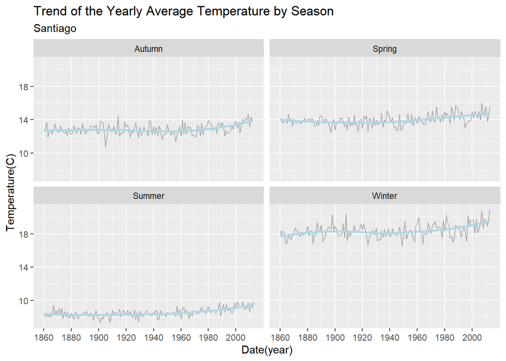

```r
city %>% group_by(season, year) %>% summarise(ave = mean(AverageTemperature)) %>% na.omit() %>%
  ggplot() + geom_line(col="dark grey") + aes(x=year, y=ave) + geom_smooth(col='light blue', se=F)+
  labs(title = "Trend of the Yearly Average Temperature by Season", subtitle="Santiago", x= "Date(year)", y="Temperature(C)")+
  scale_x_continuous(breaks = seq(1860, 2013, 20))+
  facet_wrap(~season)
```

It is above a basin deployed between the Andes Mountains of central Chile and the Coastal Mountains and is located on an elevation of 450 to 650 meters in height. It was destroyed by several disasters, but the climate is good and the scenery is beautiful, so there are many tourists. It is the political, economic, and cultural center of Chile and has a concentrated population and manufacturers. In addition to textiles, there are factories such as food processing, leather, leather, leather goods, chemicals, steel, machinery, and electrical appliances, and they collect grains, grapes, and vegetables produced in fertile central reservoirs around them. Balparaiso, about 150 kilometers west of the city, is Santiago’s outer port. The terminating railway runs from Akike in the north to Pertomont in the south, and is also connected to the Andes Transboundary Railway, which leads to Valparaiso and Buenos Aires. There is an airport in Los Seriyoos, a suburb in the southwest. (highlands,Coast-Pacific)